# ME315 - Trabalho Final

Leitura/Manipulação de Dados em Python

Benilton Carvalho, Tatiana Benaglia

2º semestre de 2020

## Introdução

A coleta de dados em épocas mais recentes teve seu custo reduzido e volume ampliado significativamente. Redes sociais combinadas com dispositivos móveis rastreiam bilhões de pessoas no mundo, com informações das mais diversas origens: rotinas de passeio, amizades, históricos de compras, históricos de localização, fotografias geo-referenciadas, etc (FYI: com o escândalo da Cambridge Analytica, surgiram evidências de que o Facebook tenha registros de histórico de chamadas e SMS, para mensagem e ligações ocorridas fora do aplicativo Facebook, em telefones Android: https://www.theverge.com/2018/3/25/17160944/facebook-call-history-sms-data-collection-android). Empresas, por meio de programas de fidelidade, aprendem hábitos de compras, propensidade de compras de certos produtos dependendo de horários, produtos que são comprados juntos e informações financeiras referentes a pagamentos. Desta maneira, o volume das bases de dados cresce vertiginosamente, de modo que é necessária a mudança de paradigma na estatística moderna: os dados não mais podem trafegar até o analista de dados; a análise deve ser transportada até os dados.

## Objetivos

Ao fim desta atividade, usando o `Python`, você deve ser capaz de:

- Importar um arquivo volumoso por partes;
- Calcular estatísticas suficientes para métrica de interesse em cada uma das partes importadas;
- Manter em memória apenas o conjunto de estatísticas suficientes e utilizar a memória remanescente para execução de cálculos;
- Combinar as estatísticas suficientes de modo a compor a métrica de interesse.

## Tarefa

Utilizando o conjunto de dados `flights.csv.zip`, disponível no site da disciplina https://me315-unicamp.github.io/ em Arquivos, vocês irão ler 100.000 observações por vez e determinar o percentual de vôos por Cia. Aérea que apresentou atraso na chegada (`ARRIVAL_DELAY`) superior a 10 minutos. As companhias a serem utilizadas são: AA, DL, UA e US. A estatística de interesse deve ser calculada para cada um dos dias de 2015. Os resultados para cada Cia. Aérea devem ser apresentados em um gráfico.

## Instruções

1. Quais são as estatísticas suficientes para a determinação do percentual de vôos atrasados na chegada (`ARRIVAL_DELAY > 10`)?

```r
## As estatisticas suficientes sao
## a) numero total de voos (para cada combinacao dia/mes/cia)
## b) numero de voos (dentre os apontados acima) que tem a coluna arrival_delay > 10
```

2. Utilize a função `read_csv` do `pandas` para importar o arquivo `flights.csv.zip` por partes e calcule o percentual de atraso para cada cia. aérea/mês/dia. Retorne o resultado abaixo em um `DataFrame`.
   1. Configure o tamanho do lote (*chunk*) para 100 mil registros;
   2. Configure o argumento `usecol` de forma que ele leia, diretamente do arquivo, apenas as colunas de interesse (‘AIRLINE’, ‘DAY’, ‘MONTH’ e ‘ARRIVAL_DELAY’);
   3. Para cada lote de registros:
      1. Filtre o conjunto de dados de forma que contenha apenas observações das seguintes Cias. Aéreas: AA, DL, UA e US;
      2. Remova observações que tenham valores faltantes em campos de interesse;
      3. Agrupe o conjunto de dados resultante de acordo com: dia, mês e cia. aérea;
      4. Para cada grupo em iii., determine as estatísticas suficientes apontadas no item 1;
   4. Combine as estatísticas suficientes para compor a métrica final de interesse (percentual de atraso por dia/mês/cia aérea);
   5. Retorne as informações em um `DataFrame` contendo as seguintes colunas:
      1. `AIRLINE`: sigla da companhia aérea;
      2. `MONTH` e `DAY`: mês e dia, respectivamente;
      3. `PERC`: percentual de atraso para aquela cia. aérea/mês/dia, apresentado como um número real no intervalo $[0, 1]$.

```python
import pandas as pd

resultados = []
for chunk in pd.read_csv("../dados/flights.csv.zip",
iterator=True, header = 0, chunksize=100000, usecols=['AIRLINE', 'DAY', 'MONTH', 'ARRIVAL_DELAY']):
     chunk = chunk.dropna(subset=['ARRIVAL_DELAY'])
     chunk = chunk[chunk.AIRLINE.isin(['AA', 'DL', 'UA', 'US'])]
     chunk['atraso'] = chunk['ARRIVAL_DELAY'] > 10
     resultados.append(chunk.groupby(['AIRLINE', 'MONTH', 'DAY']).atraso.agg(['sum', 'count']))
resultados = pd.concat(resultados)

resultados = resultados.groupby(['AIRLINE', 'MONTH', 'DAY']).agg({'sum': 'sum', 'count': 'sum'})
resultados['P_DELAY'] = resultados['sum']/resultados['count']
resultados = resultados.reset_index()

resultados
```

```
##      AIRLINE  MONTH  DAY  sum  count   P_DELAY
## 0         AA      1    1  514   1379  0.372734
## 1         AA      1    2  649   1508  0.430371
## 2         AA      1    3  767   1425  0.538246
## 3         AA      1    4  899   1493  0.602143
## 4         AA      1    5  733   1492  0.491287
## ...      ...    ...  ...  ...    ...       ...
## 1271      US      6   26  309   1181  0.261643
## 1272      US      6   27  346    965  0.358549
## 1273      US      6   28  280   1077  0.259981
## 1274      US      6   29  208   1192  0.174497
## 1275      US      6   30  400   1177  0.339847
##
## [1276 rows x 6 columns]
```

3. Usando a biblioteca `plotnine`, produza um conjunto de gráficos de linhas (usando o `ggplot`) para representar o percentual de atrasos para cada Cia. Aérea, dia e mês de 2015, em que:
   1. Cada mês deve estar representado em um gráfico, ou seja, use `facet_wrap` nos meses;
   2. O eixo `x` representa os dias do mês e o eixo `y` o percentual de atraso para aquele mês e dia;
   3. As cores das linhas representam as Cia. Aéreas;
   4. Lembre-se de adicionar um título para o seu gráfico e especificar os eixos e legenda.

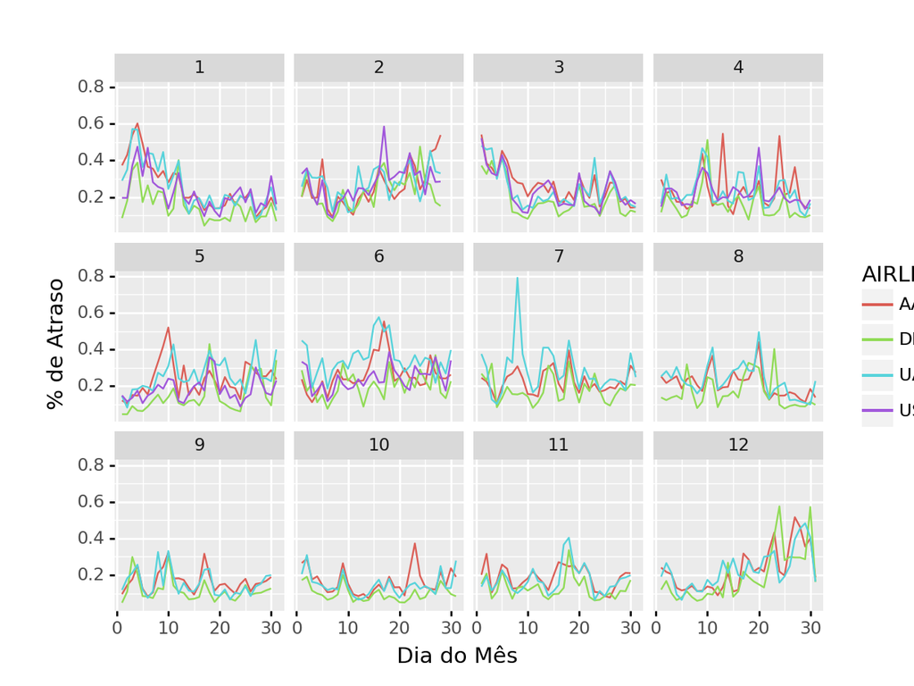

```python
from plotnine import ggplot, aes, geom_line, facet_wrap, xlab, ylab

ggplot(resultados) + geom_line(aes(x = 'DAY', y = 'P_DELAY', color='AIRLINE')) + facet_wrap(['MONTH']) + ylab('% de Atraso') + xlab('Dia do Mês')
```